# Slowing down in recovery of phytoplankton community due to recurrent heatwaves

Francesco Polazzo

16 October, 2024

# 1 Introduction

With this article we wanted to test two major ecological framework that are commonly applied to systems facing repeated perturbations:

- Critical slowing down (https://www.journals.uchicago.edu/doi/full/10.1086/516845) (https://www.nature.com/articles/nature10723)
- Community rescue (https://www.nature.com/articles/s41559-020-1134-5)

For this we used data coming from an outdoor pond mesocosm experiment (2021 Spain) where a semi-natural phytoplankton community was exposed to three subsequent heatwaves. Heatwaves are becoming more frequent and more intense, rising concerns about whether and how natural communities can face these perturbations and keep performing their functions. Critically, increasing research is suggesting that heatwaves can cause ecological systems to transition.

This transitions, also called tipping points, represent particular points at which complex systems can shift abruptly from one state to another, and they are notoriously difficult to predict. Attention has thus turned to inferring process from pattern – identifying phenomenological signals in measurable aspect of a biological system that indicates shifts in the under-lying processes that may alter the structure and function of the system. A key development in the search for such pattern-based indicators is early warning signals (EWSs) derived from dynamic systems theory (all Scheffer’s papers)

Theory proposes that early warning signals may be based on the phenomenon that recovery rates from perturbations should tend to zero when approaching a tipping point. However, evidence that this happens in living systems is scarce (at best).

Community rescue occurs when ecological or evolutionary processes restore positive growth in a highly stressful environment that was lethal to the community in its ancestral form, thus averting biomass collapse in a deteriorating environment. Very few empirical examples exist about community rescue, yet it is though to be one key mechanism that increases stress resistance in communities and contribute maintaining aggregate community properties such as biomass under stressful conditions.

Here we test whether a semi-natural phytoplankton community undergoing repeated heatwave perturbation shows signs of critical slowing down or community rescue.

# 2 Results

## 2.1 Water temperature time series

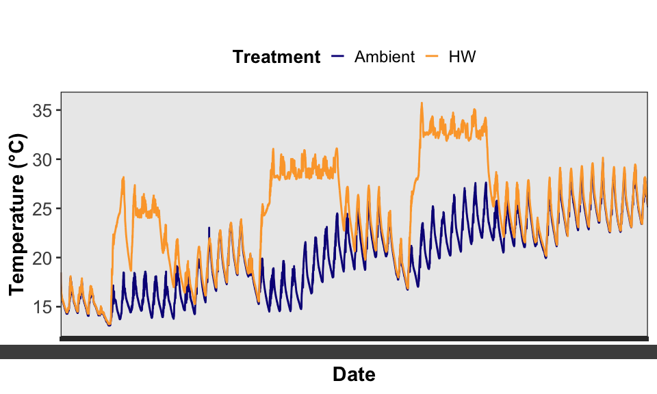

(#fig:temperature_plot)Water temperature dynamics over time.

The water temperature manipulation using the TENTACLE machinery [https://www.sciencedirect.com/science/article/pii/S2468067222000529] worked quite well.

## 2.2 Ecosystem property

### 2.2.1 Oxygen concentration

Oxygen shows an impaired recovery after the third heatwave. The contrast with the first two heatwave is striking. Indeed, the first two heatwaves determined a decline in DO only while happening, with DO quickly returning to levels higher than the control. The third heatwave strongly decreased DO during its course, and slowed down its recovery in the post HW phase so that it never got back to control levels.

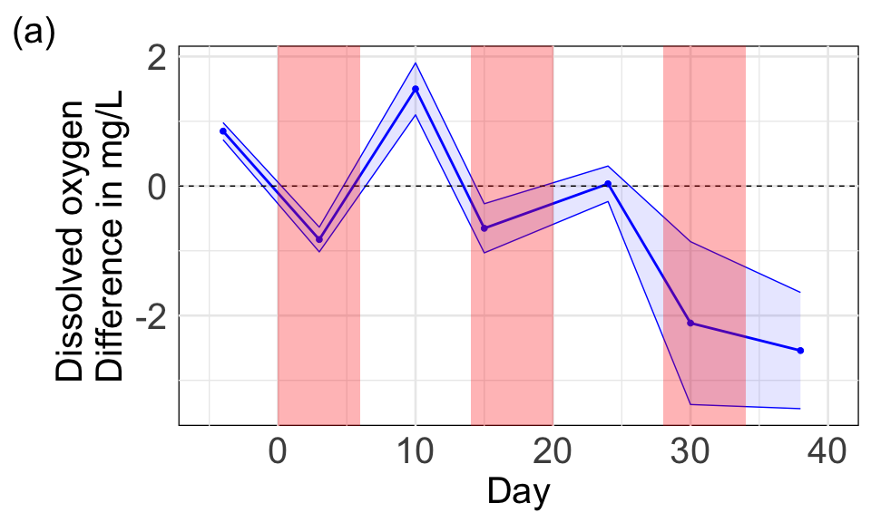

(#fig:oxygen_plot)Oxygen concetration dynamics over time. The red areas show the three heatwaves. The figure shows the difference in DO between mesocosm undergoing the HWs treatment and the control (dashed line at zero).

We now look specifically at how resilience changes after each HW. To do that we use the method describes in (Beart et al. 2016) [https://esajournals.onlinelibrary.wiley.com/doi/10.1002/ecy.1601]. Using this method, resilience is >1 when functional differences between the control and HW treatment decrease between before and after the HW, and <1 otherwise.

Summary plot for the manuscript

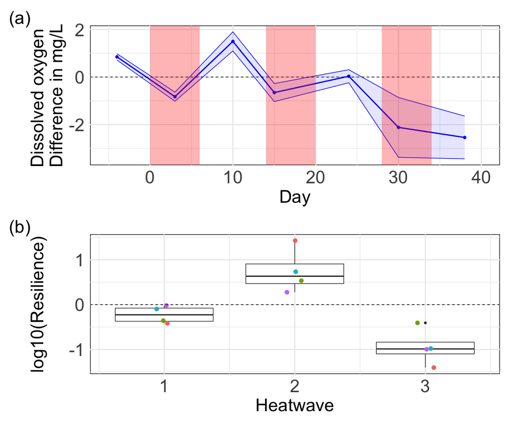

(#fig:oxy_combined)combined plot for manuscript

Creating model for oxygen

```r
ox_mod <- ox %>% filter(Day %in% c(-4, 10, 24, 38))
model_ox <- lmer(log(ox) ~ Treatment * Day + (1 | Cosm), data = ox_mod)
```

Model diagnostics

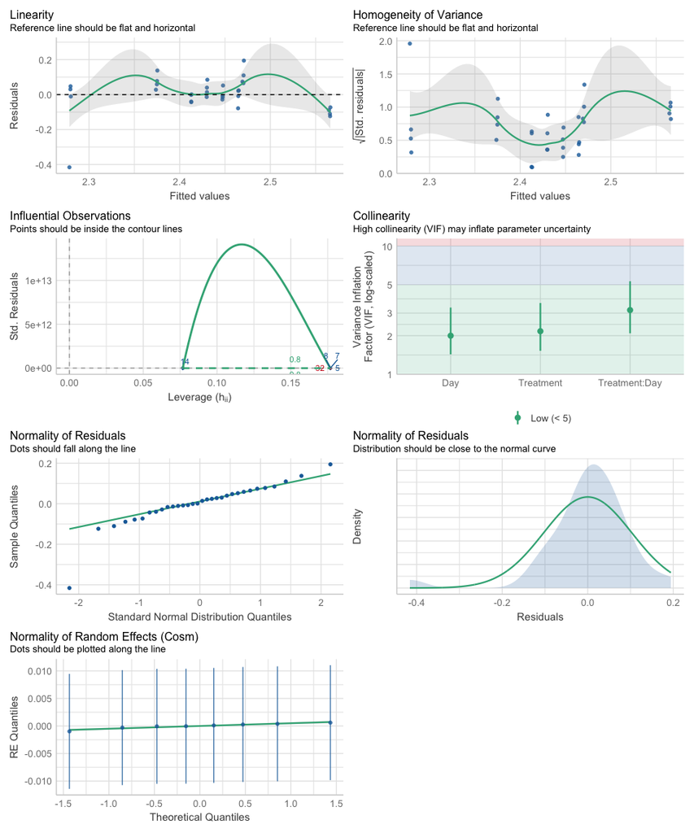

(#fig:check_ox_model)Checking assumption for oxygen model

Not bad.

|  | effect | group | term | estimate | std.error | statistic | df | p.value | 2.5% | 97.5% |
| --- | --- | --- | --- | --- | --- | --- | --- | --- | --- | --- |
| (Intercept) | fixed | NA | (Intercept) | 2.418 | 0.040 | 60.210 | 20.556 | 0.000 | 2.342 | 2.494 |
| TreatmentHW | fixed | NA | TreatmentHW | 0.121 | 0.057 | 2.124 | 20.556 | 0.046 | 0.013 | 0.228 |
| Day | fixed | NA | Day | 0.001 | 0.002 | 0.713 | 22.000 | 0.483 | -0.002 | 0.005 |
| TreatmentHW:Day | fixed | NA | TreatmentHW:Day | -0.008 | 0.002 | -3.284 | 22.000 | 0.003 | -0.013 | -0.003 |

| contrast | Day | estimate | SE | df | t.ratio | p.value |
| --- | --- | --- | --- | --- | --- | --- |
| Control - HW | -4 | -0.153 | 0.064 | 24.889 | -2.376 | 0.026 |
| Control - HW | 10 | -0.040 | 0.042 | 8.521 | -0.950 | 0.368 |
| Control - HW | 24 | 0.073 | 0.042 | 8.521 | 1.721 | 0.121 |
| Control - HW | 38 | 0.185 | 0.064 | 24.889 | 2.882 | 0.008 |

Visualization of model prediction (linear trend)

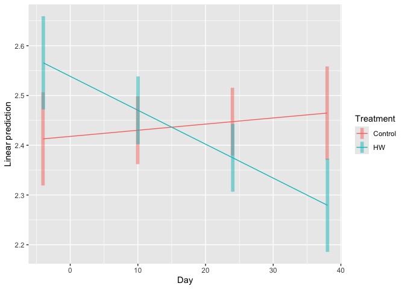

### 2.2.2 Chlorophyll - a

Chlorophyll - a shows probably the most dramatic response. There is not much change happening until the third heatwave, which determines a drop in chlorphyll - a. This strong decline reflect the compositional change and especially the reduction in biomass.

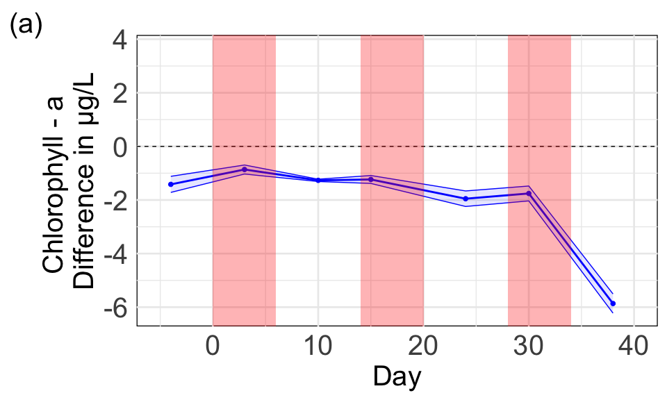

(#fig:chlorophyll_plot)CHlorophyll-a dynamics over time. The red areas show the three heatwaves

Summary plot for the manuscript Chla shows reduced resilience after each heatwave, indicating that the functional differences between the control and HW treatment increase after each HW.

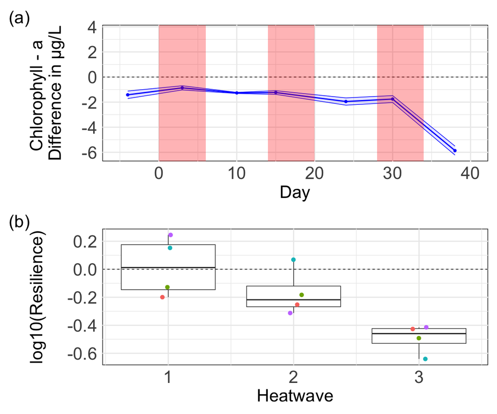

(#fig:chla_combined)combined plot for manuscript

Creating model for chla

```r
model_chla <- lmer(log(chla) ~ Treatment * Day + (1 | Cosm), data = chla)
```

|  | effect | group | term | estimate | std.error | statistic | df | p.value | 2.5% | 97.5% |
| --- | --- | --- | --- | --- | --- | --- | --- | --- | --- | --- |
| (Intercept) | fixed | NA | (Intercept) | 0.657 | 0.214 | 3.071 | 25.799 | 0.005 | 0.252 | 1.062 |
| TreatmentHW | fixed | NA | TreatmentHW | -0.650 | 0.303 | -2.148 | 25.799 | 0.041 | -1.222 | -0.078 |
| Day | fixed | NA | Day | 0.011 | 0.010 | 1.108 | 46.000 | 0.274 | -0.008 | 0.029 |
| TreatmentHW:Day | fixed | NA | TreatmentHW:Day | -0.020 | 0.014 | -1.440 | 46.000 | 0.157 | -0.046 | 0.007 |

Model diagnostics

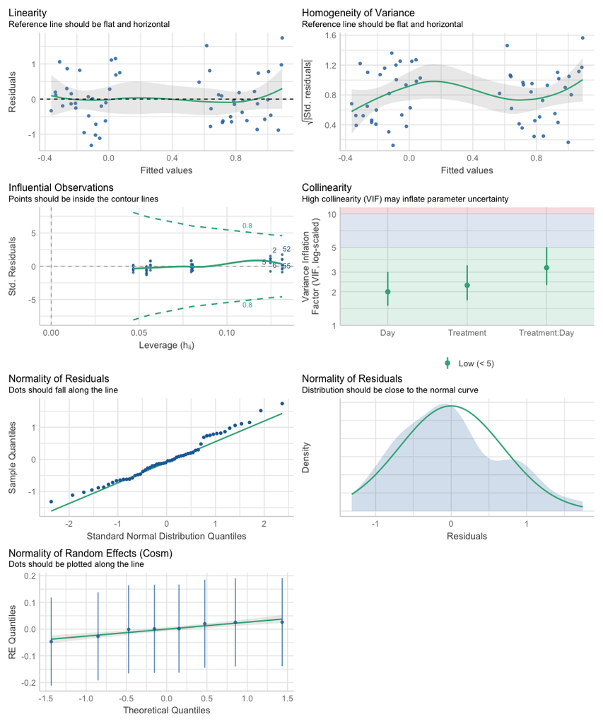

(#fig:check_chla_model)Checking assumption for chlorophyll - a model

Not too bad, but homogeneity of variance a bit messy. Consider transformation.

| contrast | Day | estimate | SE | df | t.ratio | p.value |
| --- | --- | --- | --- | --- | --- | --- |
| Control - HW | -4 | 0.571 | 0.346 | 35.284 | 1.652 | 0.107 |
| Control - HW | 3 | 0.709 | 0.273 | 18.979 | 2.596 | 0.018 |
| Control - HW | 10 | 0.847 | 0.219 | 8.627 | 3.861 | 0.004 |
| Control - HW | 15 | 0.946 | 0.201 | 6.140 | 4.700 | 0.003 |
| Control - HW | 24 | 1.123 | 0.225 | 9.421 | 5.004 | 0.001 |
| Control - HW | 30 | 1.242 | 0.272 | 18.681 | 4.569 | 0.000 |
| Control - HW | 38 | 1.400 | 0.355 | 37.154 | 3.940 | 0.000 |

Visualization of model prediction (linear trend)

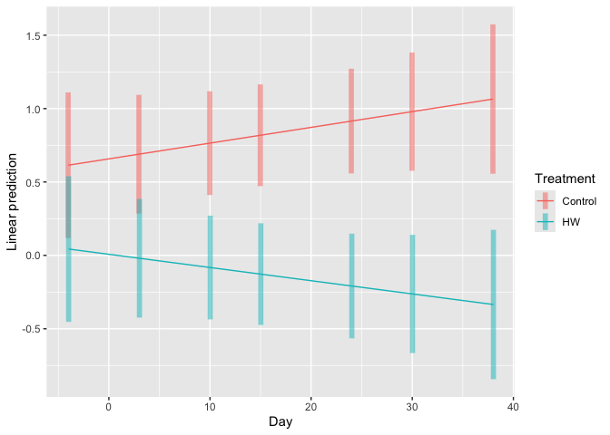

## 2.3 Compositional dynamics

### 2.3.1 Total phytoplankton biomass dynamics

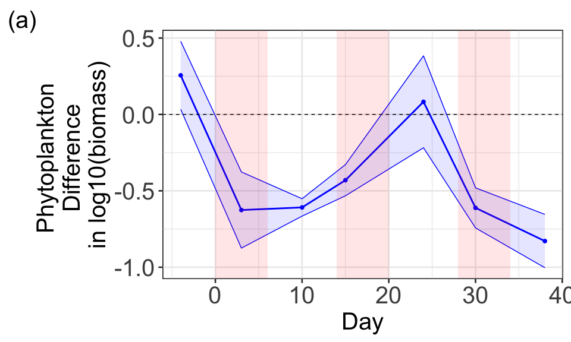

(#fig:phyto_bio_plot)Phytoplankton biomass dynamics over time. The red areas show the three heatwaves

We now look specifically at how resilience changes after each HW. Same method as above.

Summary plot for the manuscript Phytoplankton biomass shows reduced resilience after the third heatwave, indicating that the functional differences between the control and HW treatment was increased after each the last HW.

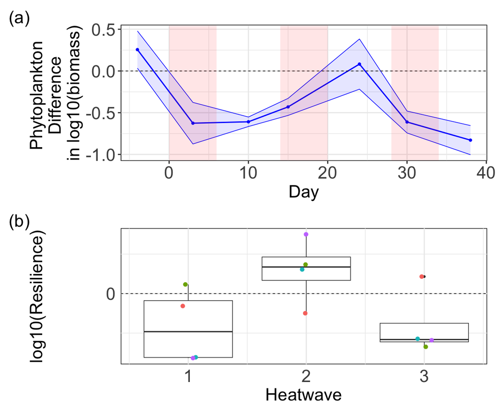

(#fig:phyto_combined)combined plot for manuscript

Creating model for phyto biomass

```r
model_phyto_bio <- lmer(log10(total) ~ Treatment * Day + (1 | Sample), data = try)
```

|  | effect | group | term | estimate | std.error | statistic | df | p.value | 2.5% | 97.5% |
| --- | --- | --- | --- | --- | --- | --- | --- | --- | --- | --- |
| (Intercept) | fixed | NA | (Intercept) | 2.445 | 0.113 | 21.677 | 52 | 0.000 | 2.229 | 2.662 |
| TreatmentHW | fixed | NA | TreatmentHW | -0.180 | 0.160 | -1.131 | 52 | 0.263 | -0.487 | 0.126 |
| Day | fixed | NA | Day | 0.002 | 0.005 | 0.318 | 52 | 0.752 | -0.008 | 0.012 |
| TreatmentHW:Day | fixed | NA | TreatmentHW:Day | -0.013 | 0.007 | -1.755 | 52 | 0.085 | -0.027 | 0.001 |

Post - hoc analysis. Let see when the HW treatment had a significant impact on phyto abundance

| contrast | Day | estimate | SE | df | t.ratio | p.value |
| --- | --- | --- | --- | --- | --- | --- |
| Control - HW | -4 | 0.129 | 0.183 | 37.643 | 0.702 | 0.487 |
| Control - HW | 3 | 0.219 | 0.143 | 20.521 | 1.531 | 0.141 |
| Control - HW | 10 | 0.310 | 0.113 | 8.935 | 2.736 | 0.023 |
| Control - HW | 15 | 0.375 | 0.103 | 6.155 | 3.636 | 0.010 |
| Control - HW | 24 | 0.491 | 0.116 | 9.827 | 4.230 | 0.002 |
| Control - HW | 30 | 0.569 | 0.143 | 20.192 | 3.993 | 0.001 |
| Control - HW | 38 | 0.673 | 0.188 | 39.467 | 3.571 | 0.001 |

Model diagnostics

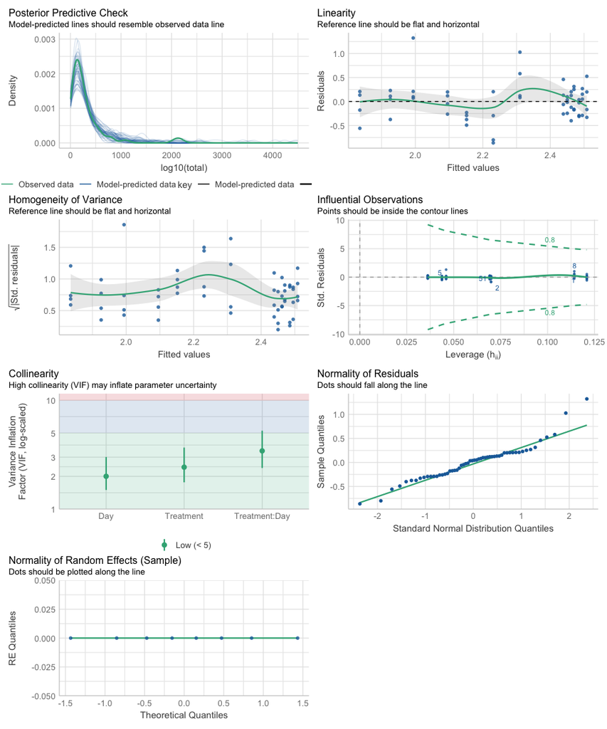

Not too bad, but homogeneity of variance a bit messy. Consider transformation.

Post - hoc analysis. Let see when the HW treatment had a significant impact on phyto abundance

| contrast | Day | estimate | SE | df | t.ratio | p.value |
| --- | --- | --- | --- | --- | --- | --- |
| Control - HW | -4 | 0.129 | 0.183 | 37.643 | 0.702 | 0.487 |
| Control - HW | 3 | 0.219 | 0.143 | 20.521 | 1.531 | 0.141 |
| Control - HW | 10 | 0.310 | 0.113 | 8.935 | 2.736 | 0.023 |
| Control - HW | 15 | 0.375 | 0.103 | 6.155 | 3.636 | 0.010 |
| Control - HW | 24 | 0.491 | 0.116 | 9.827 | 4.230 | 0.002 |
| Control - HW | 30 | 0.569 | 0.143 | 20.192 | 3.993 | 0.001 |
| Control - HW | 38 | 0.673 | 0.188 | 39.467 | 3.571 | 0.001 |

### 2.3.2 Relative biomass

Now we want to see if this gradual decline in oxygen and chla is related to taxonomic differences. We start looking at the relative biomass of different phytoplankton group over time

Let’s have a look at how different taxonomic groups of phytoplankton change over time in terms of relative biomass

The relative abundance of different groups changes largely over time, and may align with the drop in ecosystem functioning endpoints.

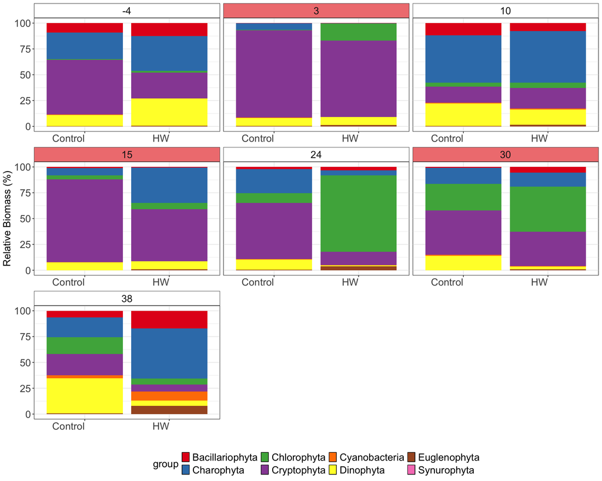

(#fig:relative_abundance_plot)Change in relative abundance of phytoplankton groups over time in the control and heatwave treatment

we now look if this visual turnover in relative groups biomass is statistically significant

### 2.3.3 PERMANOVA

| Day | df_model | df_residual | F | R2 | p_value |
| --- | --- | --- | --- | --- | --- |
| -4 | 1 | 6 | 0.895 | 0.130 | 0.367 |
| 3 | 1 | 6 | 3.091 | 0.340 | 0.067 |
| 10 | 1 | 6 | 4.376 | 0.422 | 0.027 |
| 15 | 1 | 6 | 1.766 | 0.227 | 0.150 |
| 24 | 1 | 6 | 0.783 | 0.115 | 0.569 |
| 30 | 1 | 6 | 3.109 | 0.341 | 0.032 |
| 38 | 1 | 6 | 2.553 | 0.298 | 0.026 |

### 2.3.4 SIMPER

SIMPER analysis - results and biomass comparison by day

Table results Day -4

Table 2.1: SIMPER Analysis Results for Day -4: HW vs Control

|  | species | average | sd | ratio | ava | avb | cumsum | p |
| --- | --- | --- | --- | --- | --- | --- | --- | --- |
| Charophyta | Charophyta | 0.206 | 0.171 | 1.207 | 293.749 | 99.457 | 0.371 | 0.401 |
| Dinophyta | Dinophyta | 0.133 | 0.131 | 1.013 | 228.716 | 42.859 | 0.611 | 0.083 |
| Cryptophyta | Cryptophyta | 0.133 | 0.104 | 1.273 | 215.925 | 206.102 | 0.850 | 0.319 |
| Bacillariophyta | Bacillariophyta | 0.072 | 0.036 | 2.011 | 109.057 | 35.663 | 0.980 | 0.177 |
| Chlorophyta | Chlorophyta | 0.007 | 0.006 | 1.157 | 14.110 | 2.809 | 0.992 | 0.728 |
| Euglenophyta | Euglenophyta | 0.003 | 0.004 | 0.695 | 6.179 | 0.373 | 0.997 | 0.428 |
| Cyanobacteria | Cyanobacteria | 0.002 | 0.002 | 0.768 | 0.559 | 1.160 | 1.000 | 0.875 |
| Synurophyta | Synurophyta | 0.000 | 0.000 | NaN | 0.000 | 0.000 | 1.000 | 0.001 |

Table results Day 3

Table 2.2: SIMPER Analysis Results for Day 3: HW vs Control

|  | species | average | sd | ratio | ava | avb | cumsum | p |
| --- | --- | --- | --- | --- | --- | --- | --- | --- |
| Cryptophyta | Cryptophyta | 0.513 | 0.289 | 1.779 | 75.579 | 230.067 | 0.741 | 0.051 |
| Dinophyta | Dinophyta | 0.076 | 0.091 | 0.834 | 8.011 | 21.363 | 0.850 | 0.332 |
| Chlorophyta | Chlorophyta | 0.047 | 0.081 | 0.584 | 16.870 | 1.239 | 0.919 | 0.908 |
| Charophyta | Charophyta | 0.042 | 0.062 | 0.682 | 0.342 | 17.338 | 0.980 | 0.037 |
| Cyanobacteria | Cyanobacteria | 0.007 | 0.010 | 0.642 | 0.000 | 1.684 | 0.990 | 0.001 |
| Euglenophyta | Euglenophyta | 0.005 | 0.006 | 0.766 | 1.439 | 0.804 | 0.997 | 0.944 |
| Bacillariophyta | Bacillariophyta | 0.002 | 0.003 | 0.705 | 0.186 | 0.747 | 1.000 | 0.370 |
| Synurophyta | Synurophyta | 0.000 | 0.000 | NaN | 0.000 | 0.000 | 1.000 | 0.001 |

Table results Day 10

Table 2.3: SIMPER Analysis Results for Day 10: HW vs Control

|  | species | average | sd | ratio | ava | avb | cumsum | p |
| --- | --- | --- | --- | --- | --- | --- | --- | --- |
| Charophyta | Charophyta | 0.272 | 0.237 | 1.147 | 32.657 | 135.963 | 0.407 | 0.031 |
| Dinophyta | Dinophyta | 0.148 | 0.121 | 1.224 | 9.747 | 65.023 | 0.628 | 0.053 |
| Cryptophyta | Cryptophyta | 0.146 | 0.108 | 1.347 | 13.064 | 45.836 | 0.846 | 0.001 |
| Bacillariophyta | Bacillariophyta | 0.072 | 0.078 | 0.926 | 5.035 | 34.741 | 0.954 | 0.001 |
| Chlorophyta | Chlorophyta | 0.023 | 0.025 | 0.911 | 3.339 | 11.008 | 0.988 | 0.184 |
| Cyanobacteria | Cyanobacteria | 0.005 | 0.007 | 0.803 | 0.550 | 2.366 | 0.996 | 0.946 |
| Euglenophyta | Euglenophyta | 0.003 | 0.004 | 0.713 | 1.014 | 0.765 | 1.000 | 0.975 |
| Synurophyta | Synurophyta | 0.000 | 0.000 | NaN | 0.000 | 0.000 | 1.000 | 0.001 |

Table results Day 15

Table 2.4: SIMPER Analysis Results for Day 15: HW vs Control

|  | species | average | sd | ratio | ava | avb | cumsum | p |
| --- | --- | --- | --- | --- | --- | --- | --- | --- |
| Cryptophyta | Cryptophyta | 0.430 | 0.249 | 1.729 | 68.053 | 307.782 | 0.687 | 0.120 |
| Charophyta | Charophyta | 0.091 | 0.089 | 1.021 | 46.209 | 26.590 | 0.832 | 0.949 |
| Dinophyta | Dinophyta | 0.063 | 0.077 | 0.808 | 10.681 | 29.374 | 0.932 | 0.062 |
| Chlorophyta | Chlorophyta | 0.030 | 0.024 | 1.232 | 8.345 | 15.295 | 0.980 | 0.403 |
| Bacillariophyta | Bacillariophyta | 0.009 | 0.008 | 1.069 | 0.773 | 4.510 | 0.993 | 0.113 |
| Euglenophyta | Euglenophyta | 0.003 | 0.004 | 0.626 | 1.057 | 0.000 | 0.998 | 0.893 |
| Cyanobacteria | Cyanobacteria | 0.001 | 0.001 | 2.037 | 0.002 | 0.639 | 1.000 | 0.001 |
| Synurophyta | Synurophyta | 0.000 | 0.000 | NaN | 0.000 | 0.000 | 1.000 | 0.001 |

Table results Day 24

Table 2.5: SIMPER Analysis Results for Day 24: HW vs Control

|  | species | average | sd | ratio | ava | avb | cumsum | p |
| --- | --- | --- | --- | --- | --- | --- | --- | --- |
| Chlorophyta | Chlorophyta | 0.232 | 0.325 | 0.713 | 456.690 | 21.977 | 0.393 | 0.866 |
| Cryptophyta | Cryptophyta | 0.152 | 0.151 | 1.008 | 80.832 | 125.624 | 0.652 | 0.740 |
| Charophyta | Charophyta | 0.106 | 0.161 | 0.654 | 29.724 | 53.875 | 0.831 | 0.543 |
| Dinophyta | Dinophyta | 0.049 | 0.050 | 0.990 | 6.142 | 23.099 | 0.915 | 0.078 |
| Euglenophyta | Euglenophyta | 0.029 | 0.037 | 0.785 | 23.128 | 1.110 | 0.964 | 0.365 |
| Bacillariophyta | Bacillariophyta | 0.019 | 0.011 | 1.748 | 21.166 | 4.900 | 0.996 | 0.459 |
| Cyanobacteria | Cyanobacteria | 0.003 | 0.003 | 0.966 | 1.106 | 0.848 | 1.000 | 0.619 |
| Synurophyta | Synurophyta | 0.000 | 0.000 | NaN | 0.000 | 0.000 | 1.000 | 0.001 |

Table results Day 30

Table 2.6: SIMPER Analysis Results for Day 30: HW vs Control

|  | species | average | sd | ratio | ava | avb | cumsum | p |
| --- | --- | --- | --- | --- | --- | --- | --- | --- |
| Cryptophyta | Cryptophyta | 0.332 | 0.264 | 1.256 | 31.725 | 165.021 | 0.452 | 0.001 |
| Chlorophyta | Chlorophyta | 0.180 | 0.169 | 1.066 | 41.734 | 99.096 | 0.697 | 0.933 |
| Charophyta | Charophyta | 0.110 | 0.158 | 0.696 | 12.816 | 59.473 | 0.847 | 0.306 |
| Dinophyta | Dinophyta | 0.095 | 0.090 | 1.055 | 2.670 | 53.407 | 0.976 | 0.058 |
| Bacillariophyta | Bacillariophyta | 0.010 | 0.009 | 1.016 | 5.289 | 3.337 | 0.989 | 0.936 |
| Cyanobacteria | Cyanobacteria | 0.006 | 0.005 | 1.127 | 0.250 | 3.758 | 0.998 | 0.113 |
| Euglenophyta | Euglenophyta | 0.002 | 0.003 | 0.519 | 0.835 | 0.000 | 1.000 | 0.971 |
| Synurophyta | Synurophyta | 0.000 | 0.000 | NaN | 0.000 | 0.000 | 1.000 | 0.001 |

Table results Day 38

Table 2.7: SIMPER Analysis Results for Day 38: HW vs Control

|  | species | average | sd | ratio | ava | avb | cumsum | p |
| --- | --- | --- | --- | --- | --- | --- | --- | --- |
| Cryptophyta | Cryptophyta | 0.230 | 0.162 | 1.420 | 4.567 | 100.140 | 0.304 | 0.001 |
| Dinophyta | Dinophyta | 0.173 | 0.194 | 0.895 | 3.471 | 167.298 | 0.533 | 0.147 |
| Chlorophyta | Chlorophyta | 0.130 | 0.166 | 0.783 | 3.894 | 80.553 | 0.704 | 0.039 |
| Charophyta | Charophyta | 0.127 | 0.055 | 2.308 | 32.507 | 93.918 | 0.872 | 0.967 |
| Bacillariophyta | Bacillariophyta | 0.059 | 0.047 | 1.260 | 11.421 | 31.128 | 0.950 | 0.429 |
| Cyanobacteria | Cyanobacteria | 0.027 | 0.024 | 1.147 | 5.863 | 14.455 | 0.986 | 0.967 |
| Euglenophyta | Euglenophyta | 0.011 | 0.010 | 1.004 | 5.281 | 3.097 | 1.000 | 0.929 |
| Synurophyta | Synurophyta | 0.000 | 0.000 | NaN | 0.000 | 0.000 | 1.000 | 0.001 |

### 2.3.5 NMDS plot

Not sure if this makes sense, as the change in relative biomass plot looks much nicer

[figure not shown]

## 2.4 Zooplankton

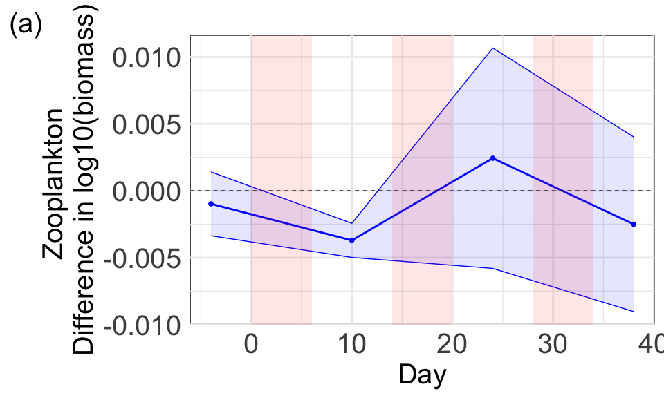

(#fig:bio_plot_zoo)Zooplankton biomass dynamics over time. The red areas show the three heatwaves

Creating model for zoo biomass

```r
dd_zoo_model <- dd_zoo_long %>%
  group_by(Mesocosm.No, Treatment, Day) %>%
  summarize(total = sum(biomass)) %>%
  ungroup()
model_zoo_bio <- lmer(log10(total +1) ~ Treatment * Day + (1 | Mesocosm.No), data = dd_zoo_model)
```

|  | effect | group | term | estimate | std.error | statistic | df | p.value | 2.5% | 97.5% |
| --- | --- | --- | --- | --- | --- | --- | --- | --- | --- | --- |
| (Intercept) | fixed | NA | (Intercept) | 0.142 | 0.048 | 2.928 | 28 | 0.007 | 0.050 | 0.234 |
| TreatmentHW | fixed | NA | TreatmentHW | -0.029 | 0.069 | -0.419 | 28 | 0.678 | -0.158 | 0.101 |
| Day | fixed | NA | Day | 0.006 | 0.002 | 2.859 | 28 | 0.008 | 0.002 | 0.010 |
| TreatmentHW:Day | fixed | NA | TreatmentHW:Day | 0.001 | 0.003 | 0.235 | 28 | 0.816 | -0.005 | 0.006 |

### 2.4.1 Relative biomass

Let’s have a look at how different taxonomic groups of zooplankton change over time in terms of relative biomass

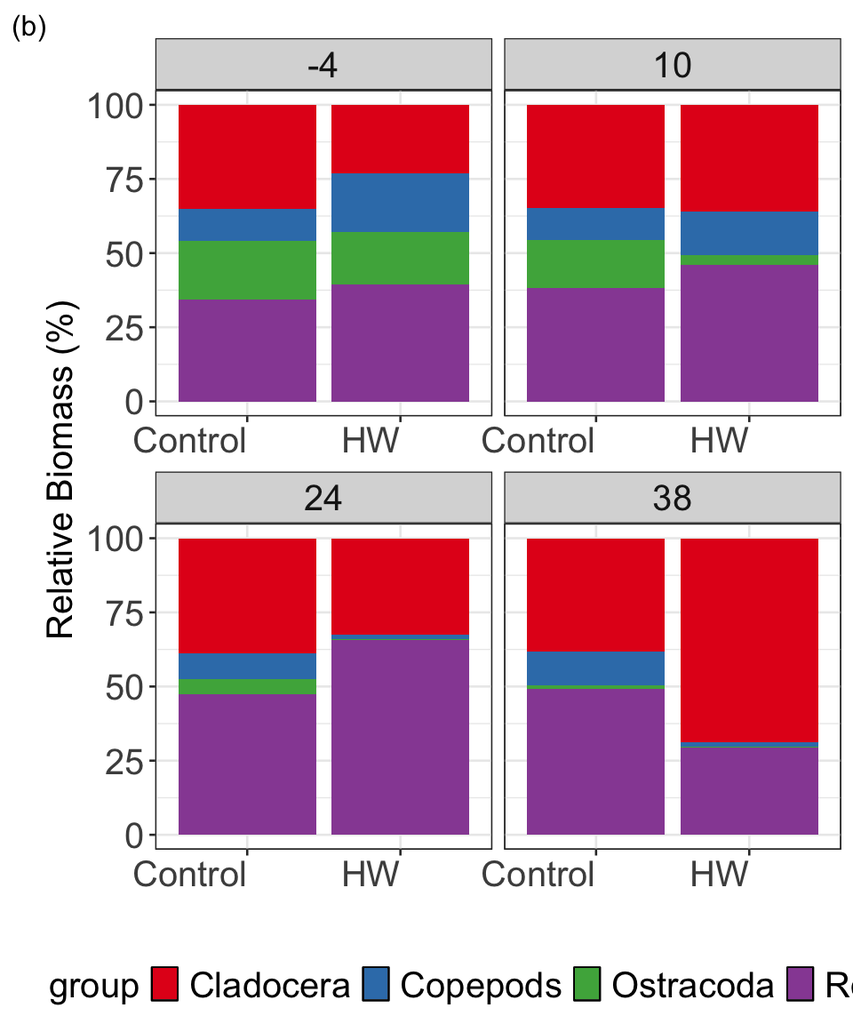

(#fig:relative_bio_zoo_plot)Change in relative biomass of zooplankton groups over time in the control and heatwave treatment

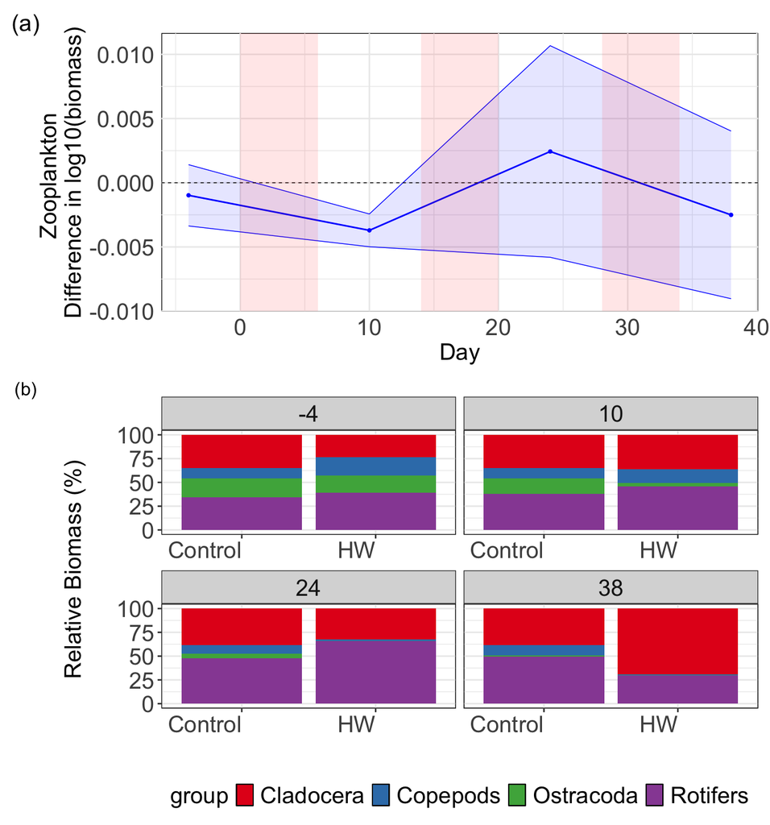

(#fig:rcombined_zoop)combined plot

### 2.4.2 PERMANOVA

| Day | df_model | df_residual | F | R2 | p_value |
| --- | --- | --- | --- | --- | --- |
| -4 | 1 | 6 | 0.241 | 0.039 | 0.670 |
| 10 | 1 | 6 | 0.547 | 0.084 | 0.732 |
| 24 | 1 | 6 | 1.228 | 0.170 | 0.194 |
| 38 | 1 | 6 | 0.713 | 0.106 | 0.609 |